# Project 2 - Analysis of Sales Data

Jumpei Fujimoto

## Description of Project

Assume that a company called Global Markets Inc. operates 127 grocery stores across the country. They collect data relating to annual sales for each of their stores. The data is stored in the data file “global.txt”. A description of the fields in this dataset is as follows:

| Variable | Description |
| --- | --- |
| **`Sales`** | Annual sales, in $1000’s. |
| **`SqFt`** | Size of store, measured in 1000’s of square feet. |
| **`Inv`** | Value of inventory, in $1000’s. |
| **`Adv`** | Annual advertising budget, in $1000’s. |
| **`Pop`** | Population served by store, in 1000’s of people. |
| **`MedInc`** | Median income of population, in $1000’s. |

Our goal in this project will be to create a multiple linear regression model that attempts to predict `Sales` as a function of some combination of the remaining five variables.

## Part A: Loading and Exploring the Data

Load the data contained in the text file into a data frame.

```r
# Replace with R code
df <- read.table("global.txt", sep="\t", header=TRUE)
```

Create a summary of the data frame.

`r`r # Replace with R code summary(df)

```
     Sales            SqFt            Inv             Adv              Pop            MedInc
 Min.   :166.3   Min.   :2.000   Min.   :170.2   Min.   : 4.800   Min.   :15.00   Min.   :37.90
 1st Qu.:219.4   1st Qu.:2.900   1st Qu.:211.0   1st Qu.: 6.750   1st Qu.:18.25   1st Qu.:43.20
 Median :241.2   Median :3.500   Median :221.0   Median : 9.600   Median :20.40   Median :45.40
 Mean   :238.3   Mean   :3.586   Mean   :221.4   Mean   : 9.587   Mean   :20.37   Mean   :45.19
 3rd Qu.:259.5   3rd Qu.:4.300   3rd Qu.:233.5   3rd Qu.:12.400   3rd Qu.:22.60   3rd Qu.:46.80
 Max.   :315.8   Max.   :5.000   Max.   :250.9   Max.   :15.000   Max.   :24.90   Max.   :53.80
```

Use `pairs()` to create a pairs plot showing scatterplots of all pairs of variables in the data frame.

`r`r # Replace with R code pairs(df)

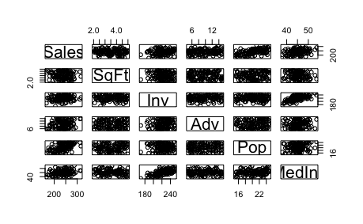

Use `cor()` to create a correlation matrix showing the correlations of all pairs of variables in the data frame.

`r`r # Replace with R code cor(df)

```
             Sales        SqFt         Inv         Adv        Pop      MedInc
Sales   1.00000000 -0.07558024  0.17035011  0.19688319 0.52722573  0.27955201
SqFt   -0.07558024  1.00000000 -0.04671033 -0.01378242 0.06171396 -0.12178388
Inv     0.17035011 -0.04671033  1.00000000  0.07034611 0.01331126  0.63526129
Adv     0.19688319 -0.01378242  0.07034611  1.00000000 0.03039263  0.04499949
Pop     0.52722573  0.06171396  0.01331126  0.03039263 1.00000000  0.15622932
MedInc  0.27955201 -0.12178388  0.63526129  0.04499949 0.15622932  1.00000000
```

**‘Pop’ valuable is the strongest linear relationship with ‘sales’ valuable. ‘MedInc’ and ‘Inv’ valuable have a strong correlation.**

## Part B: Consider the Full Model

Create a model by regressing `Sales` against all of the other five variables at once. Then display a summary of this model.

`r`r # Replace with R code mod1 <- lm(Sales ~ SqFt + Inv + Adv + Pop + MedInc, df) summary(mod1)

```
Call:
lm(formula = Sales ~ SqFt + Inv + Adv + Pop + MedInc, data = df)

Residuals:
   Min     1Q Median     3Q    Max
-58.73 -16.57   0.15  16.32  61.52

Coefficients:
            Estimate Std. Error t value Pr(>|t|)
(Intercept) 31.62891   38.89036   0.813   0.4177
SqFt        -2.96042    2.61526  -1.132   0.2599
Inv          0.09726    0.17581   0.553   0.5811
Adv          1.64262    0.70714   2.323   0.0219 *
Pop          5.60677    0.83202   6.739 5.75e-10 ***
MedInc       1.45673    0.94580   1.540   0.1261
---
Signif. codes:  0 '***' 0.001 '**' 0.01 '*' 0.05 '.' 0.1 ' ' 1

Residual standard error: 24.18 on 121 degrees of freedom
Multiple R-squared:  0.3559,    Adjusted R-squared:  0.3292
F-statistic: 13.37 on 5 and 121 DF,  p-value: 2.245e-10
```

**This model does not seem good because p- value of ‘SqFt’, ‘Inv’, and ‘MedInc’ valuables are too large.**

## Part C: Model Selection

Based on your analysis up to this point, select one of the five potential predictors and create a simple linear regression model using only this one predictor. Create a summary of the model.

`r`r # Replace with R code mod2 <- lm(Sales ~ Pop, df) summary(mod2)

```
Call:
lm(formula = Sales ~ Pop, data = df)

Residuals:
    Min      1Q  Median      3Q     Max
-61.643 -13.880   0.695  20.839  72.582

Coefficients:
            Estimate Std. Error t value Pr(>|t|)
(Intercept) 118.6652    17.3967   6.821 3.45e-10 ***
Pop           5.8751     0.8469   6.937 1.91e-10 ***
---
Signif. codes:  0 '***' 0.001 '**' 0.01 '*' 0.05 '.' 0.1 ' ' 1

Residual standard error: 25.19 on 125 degrees of freedom
Multiple R-squared:  0.278, Adjusted R-squared:  0.2722
F-statistic: 48.12 on 1 and 125 DF,  p-value: 1.914e-10
```

**This model looks better than ‘mod1’ because p-value is really small. However, it still has a problem because multiple R-squared are small.**

Now add variables into the model one at a time, creating a summary and providing an evaluation of the model at each step. If a variable that you have added fails to improve the model, then remove it and add another variable. Explain your decisions at each step.

Continue this process until you have a satisfactory model. All of the coefficients in your final model should pass their t-tests with at the 5% level of significance. Of the models satisfying this criteria, select the one with the highest adjusted r-squared value.

`r`r mod3 <- lm(Sales ~ Pop + MedInc + Adv, df) summary(mod3)

```
Call:
lm(formula = Sales ~ Pop + MedInc + Adv, data = df)

Residuals:
    Min      1Q  Median      3Q     Max
-63.694 -15.074   0.308  17.757  61.694

Coefficients:
            Estimate Std. Error t value Pr(>|t|)
(Intercept)  24.9344    34.5395   0.722   0.4717
Pop           5.4770     0.8218   6.665 7.95e-10 ***
MedInc        1.8985     0.7185   2.642   0.0093 **
Adv           1.6733     0.7046   2.375   0.0191 *
---
Signif. codes:  0 '***' 0.001 '**' 0.01 '*' 0.05 '.' 0.1 ' ' 1

Residual standard error: 24.13 on 123 degrees of freedom
Multiple R-squared:  0.3477,    Adjusted R-squared:  0.3318
F-statistic: 21.86 on 3 and 123 DF,  p-value: 2.059e-11
```

## Part D: Final Model

Provide the equation for your final model by editing the formula below. Remove any unnecessary variables and replace the zeros as appropriate.

$\hat {Sales} = 24.9344 + 5.4770 \cdot Pop + 1.8985 \cdot MedInc + 1.6733\cdot Adv$

## Part E: Residual Analysis

Create a residual plot for your final model.

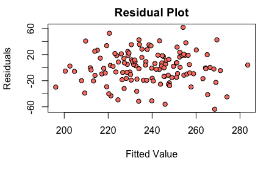

Create a histogram of the residuals in your final model, using 20 breaks.

`r`r # Replace with R code res <- mod3$residuals hist(res, col=‘orchid’, breaks=20)

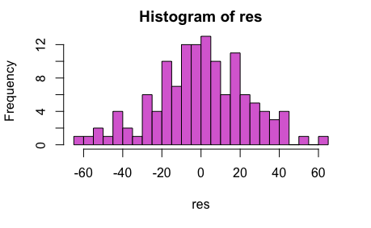

**It is a little bit left skewed distribution, however we could say that this is normal distribution.**

Create a qq-plot of the residuals in your final model.

`r`r # Replace with R code qqnorm(res) qqline(res)

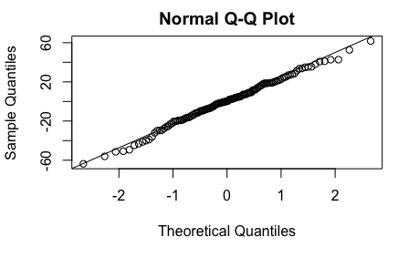

**It is a normal distribution because the many plots are on the line but few plots are less than -1 and greater than loughly 1.5, are not on the line. For my assumption, it could fix if a sample size is larger.**

## Part F: Predictions

Generate 95% prediction intervals for annual sales of stores satisfying the following criteria:

| Store | SqFt | Inv | Adv | Pop | MedInc |
| --- | --- | --- | --- | --- | --- |
| Store 1 | 2.3 | 215 | 8.4 | 14.3 | 42.6 |
| Store 2 | 4.7 | 285 | 6.8 | 15.2 | 51.8 |
| Store 3 | 3.4 | 321 | 12.7 | 22.6 | 37.9 |

```
       fit      lwr      upr
1 198.1879 149.1847 247.1911
2 217.9061 167.9049 267.9073
3 241.9196 192.3798 291.4594
```